# Data Analyst Test Task - Game Analysis Report

Puneeth Nikin Krishnan

10/07/2020

# 1 Introduction

This Analysis pertains to A/B test of a free mobile game. The focus of this analysis is to optimise time of display of shop to users. The hypothesis is that by delaying display of shop to users after they have engaged with the game, it is possible to increase retention rate and cumulative Average Revenue Per User (ARPU). To test this hypothesis users have been divided into three equal groups:  
- test_group_a : This group has access to the shop after 4 matches.  
- control_group : This group has access to the shop after 2 matches.  
- test_group_b : This group always has access to the shop.

## 1.1 Objective

The objective of this analysis is to identify the optimum time to display the shop. It is imperative to establish the relationship between the available parameters and cumulative ARPU to be able to gauge the effect modifying the controllable factors will have on the overall gameplay experience and revenue generation.

# 2 Exploratory Data Analysis

I have performed exploratory data analysis to analyse and understand the relationship between retention, conversion and revenue so as to deliver a strategy that will optimise ARPU.

## 2.1 About the DataSet

```r
if(!require(caret))
  install.packages("caret", repos = "http://cran.us.r-project.org")
if (!require(rvest))
  install.packages("rvest", repos = "http://cran.us.r-project.org")
if (!require(tidyverse))
  install.packages("tidyverse", repos = "http://cran.us.r-project.org")
if (!require(ggthemes))
  install.packages("ggthemes", repos = "http://cran.us.r-project.org")
if(!require(kableExtra))
  install.packages("kableExtra",
                   repos = "http://cran.us.r-project.org")
```

The zip file provided at [google drive](https://drive.google.com/file/d/1w8y5MFFJY6Gw7vKdsETEuXfWkAzXAapw/view?usp=sharing) contains three csv files namely :  
1. data_daily_activity.csv - This file contains daily activity of users.

```r
daily_activity<-read_csv('data/data_daily_activity.csv')
daily_activity%>%
  head(4)%>%
  knitr::kable(caption = "daily_activity")%>%
  kable_styling()
```

daily_activity

| userId | date | countryCode | platform | abTestGroup |
| --- | --- | --- | --- | --- |
| j83udscs5b5bfmb | 2020-05-03 | FR | ios | test_group_a |
| 6vmia2xkmuo7ubm | 2020-05-10 | BR | ios | test_group_a |
| kov82tsj6he7hvp | 2020-05-12 | BR | android | control_group |
| 85el8huhiwealui | 2020-05-11 | GB | android | test_group_b |

2. data_daily_matches.csv - This file contains number of matches played by each user for a given day. I added a column matches_till_date(number of matches played till date) by computing cumulative sum of matches.

```r
daily_matches<- read_csv('data/data_daily_matches.csv')
daily_matches<- daily_matches%>%group_by(userId)%>%arrange(date, .by_group = TRUE)%>%mutate(matches_till_date = cumsum(matches))
daily_matches%>%
  head(4)%>%
  knitr::kable(caption="daily_matches")%>%
  kable_styling()
```

daily_matches

| userId | date | matches | matches_till_date |
| --- | --- | --- | --- |
| 000m8owu19gmejx | 2020-05-12 | 7 | 7 |
| 000m8owu19gmejx | 2020-05-13 | 23 | 30 |
| 000m8owu19gmejx | 2020-05-14 | 14 | 44 |
| 000m8owu19gmejx | 2020-05-15 | 17 | 61 |

3. data_in_app_purchases.csv - This file contains details of purchases made by users.

```r
in_app_purchases<-read_csv('data/data_in_app_purchases.csv')
in_app_purchases%>%
  head(4)%>%
  knitr::kable(caption='in_app_purchases')%>%
  kable_styling()
```

in_app_purchases

| userId | date | product | cost |
| --- | --- | --- | --- |
| t054hrczly04vrf | 2020-05-04 | promotiondeal1 | 0.99 |
| nmkzr6rjop5igcz | 2020-05-05 | promotiondeal1 | 0.99 |
| rpa7dpseh6bddw2 | 2020-05-10 | cashinjection | 0.99 |
| sxlb2r42xb2sss0 | 2020-05-04 | cashinjection | 0.99 |

## 2.2 Wrangling

I have combined all three datasets/dataframes into one single dataframe user_data to simplify analysis.I have added two columns acquisition_date(date user was added) and days_since_acquisition(number of days passed since acquisition) to user_data.

```r
user_data <-
  daily_activity %>%
  full_join(daily_matches, by =
              c('userId', 'date')) %>%
  full_join(in_app_purchases, by =
              c('userId', 'date'))
user_data<-
  user_data %>%
  group_by(userId) %>%
  mutate(acquisition_date =  min(date))%>%
  mutate(
    days_since_acquisition = as.numeric(date - acquisition_date)
  )%>%
  filter(!is.na(abTestGroup))%>%ungroup()
user_data[complete.cases(user_data), ]%>%
  head(4)%>%
  knitr::kable(caption = 'user_data')%>%
  kable_styling()
```

user_data

| userId | date | countryCode | platform | abTestGroup | matches | matches_till_date | product | cost | acquisition_date | days_since_acquisition |
| --- | --- | --- | --- | --- | --- | --- | --- | --- | --- | --- |
| y9b1zgcb9osncmk | 2020-05-11 | ID | android | test_group_b | 19 | 132 | chairmanbonus | 0.99 | 2020-05-06 | 5 |
| y9b1zgcb9osncmk | 2020-05-11 | ID | android | test_group_b | 19 | 132 | hc3 | 19.99 | 2020-05-06 | 5 |
| pcsb2r8fkhz105x | 2020-05-04 | DE | android | test_group_a | 13 | 67 | hc1 | 4.99 | 2020-05-02 | 2 |
| pcsb2r8fkhz105x | 2020-05-04 | DE | android | test_group_a | 13 | 67 | starterpack1 | 5.49 | 2020-05-02 | 2 |

Using user_data, I have derived a new dataframe called N_Day_Analysis to perform date wise analysis and compute Retention Rate, Cumulative ARPU and Cumulative Revenue.

```r
N_Day_Analysis<-
  user_data%>%
  group_by(abTestGroup, acquisition_date, days_since_acquisition)%>%
  summarise(number_of_users = n(),
            revenue = sum(cost, na.rm = TRUE),
            conversion=sum(!is.na(cost)))%>%
  mutate(
    retention_rate = number_of_users / max(number_of_users),
    Cumulative_ARPU = cumsum(revenue) / max(number_of_users),
    Cumulative_conversion=cumsum(conversion)/max(number_of_users),
  )%>%
  ungroup()
N_Day_Analysis%>%
  head(4)%>%
  knitr::kable(caption = 'N_Day_Analysis')%>%
  kable_styling()
```

N_Day_Analysis

| abTestGroup | acquisition_date | days_since_acquisition | number_of_users | revenue | conversion | retention_rate | Cumulative_ARPU | Cumulative_conversion |
| --- | --- | --- | --- | --- | --- | --- | --- | --- |
| control_group | 2020-05-01 | 0 | 3178 | 656.81 | 169 | 1.0000000 | 0.2066740 | 0.0531781 |
| control_group | 2020-05-01 | 1 | 900 | 240.79 | 71 | 0.2831970 | 0.2824418 | 0.0755192 |
| control_group | 2020-05-01 | 2 | 639 | 395.86 | 64 | 0.2010699 | 0.4070044 | 0.0956576 |
| control_group | 2020-05-01 | 3 | 496 | 180.92 | 58 | 0.1560730 | 0.4639333 | 0.1139081 |

## 2.3 Analyse Relationship between different parameters

### 2.3.1 Correlation Analysis (Number of users and Revenue)

While it is intuitive that more number of active users will lead to higher revenue it is critical to analyse the relationship.

```r
cor(N_Day_Analysis[c('revenue','conversion','retention_rate')])
```

```
##                  revenue conversion retention_rate
## revenue        1.0000000  0.8838052      0.7651753
## conversion     0.8838052  1.0000000      0.7738279
## retention_rate 0.7651753  0.7738279      1.0000000
```

The correlation matrix shows that all the parameters are positively correlated. A higher retention rate will lead to higher conversion and consequently higher revenues.

### 2.3.2 Analyse cumulative ARPU for groups

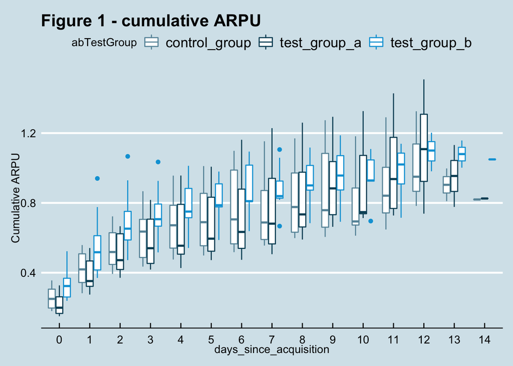

```r
N_Day_Analysis%>%
  ggplot(aes(as.factor(days_since_acquisition), Cumulative_ARPU, col = abTestGroup))+
  geom_boxplot()+
  ggtitle("Figure 1 - cumulative ARPU")+
  xlab('days_since_acquisition')+
  ylab('Cumulative ARPU')+
  theme_economist() +
  scale_colour_economist()
```

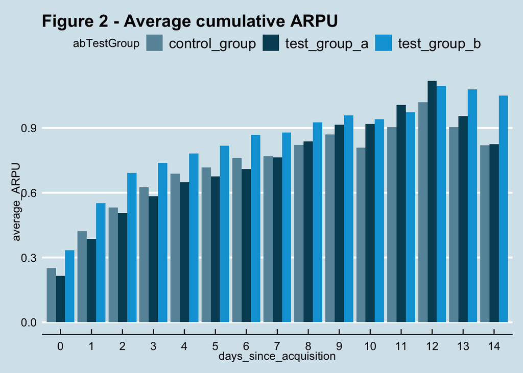

```r
N_Day_Analysis%>%
  group_by(abTestGroup,days_since_acquisition)%>%
  summarise(average_ARPU=mean(Cumulative_ARPU))%>%
  ungroup()%>%
  ggplot(aes(as.factor(days_since_acquisition),average_ARPU,fill=abTestGroup))+
  geom_col(position = 'dodge')+
  xlab('days_since_acquisition')+
  ggtitle("Figure 2 - Average cumulative ARPU")+
  theme_economist() +
  scale_colour_economist()+scale_fill_manual(values=c("#6794a7","#014d64","#01a2d9"))
```

### 2.3.3 Analyse retention rate for groups

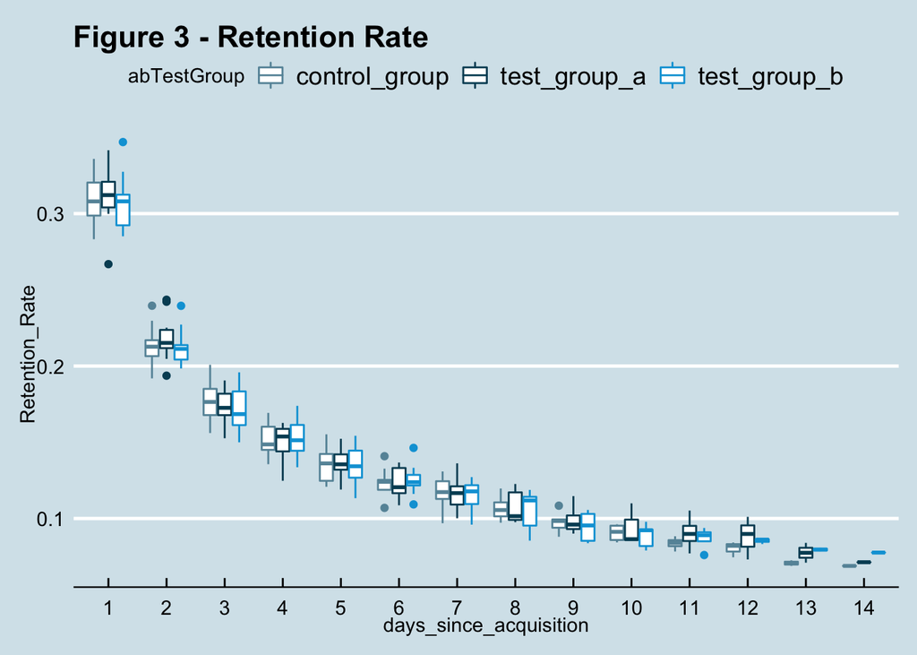

```r
N_Day_Analysis%>%
  filter(days_since_acquisition >0)%>%
  ggplot(aes(as.factor(days_since_acquisition), retention_rate, col = abTestGroup))+
  geom_boxplot()+
  ggtitle("Figure 3 - Retention Rate")+
  xlab('days_since_acquisition')+
  ylab('Retention_Rate')+
  theme_economist() +
  scale_colour_economist()
```

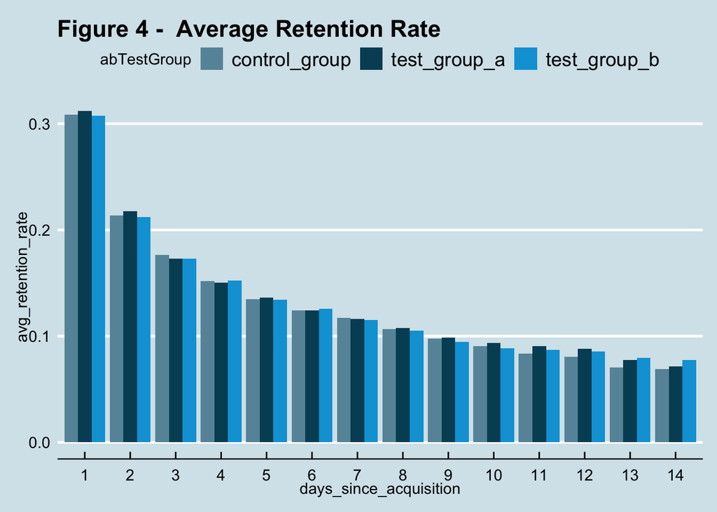

```r
N_Day_Analysis%>%
  filter(days_since_acquisition!=0)%>%
  group_by(abTestGroup,days_since_acquisition)%>%
  summarise(avg_retention_rate=mean(retention_rate))%>%
  ggplot(aes(as.factor(days_since_acquisition),avg_retention_rate,fill=abTestGroup))+
  geom_col(position = 'dodge')+
  xlab('days_since_acquisition')+
  ggtitle("Figure 4 -  Average Retention Rate")+
  theme_economist() +
  scale_colour_economist()+scale_fill_manual(values=c("#6794a7","#014d64","#01a2d9"))
```

Retention rate for test_group_a and control_group is marginally higher in the two days since acquisition with a higher median value as seen in Figure 3 .Figure 3 shows that retention rate drops rapidly during the period of analysis for all groups in general. Therefore the possibility of conversion also decreases with similar rates due to high correlation among these parameters. However it is also to be noted that the difference in retention rate among the groups is minimal in the long run as can be seen in Figure 4.

## 2.4 Optimum Number of Matches Prior to display of Shop

It is clear from this analysis that higher retention rate can lead to higher conversion rates and consequently higher Cumulative ARPU. While it can be seen that delaying the display of shop has a potential increase in retention rates in the first few days since acquisition, there could be a loss in revenue when the shop is not displayed. A strategy needs to be devised that balances the need for revenue while maintaining retention rates.

To achieve this goal, analysis for number of matches prior to purchase of a product is performed.

### 2.4.1 Assumption

The dataframe user_data contains total number of matches played for a given day and if a product has been purchased on that day. I have assumed that the product has been purchased at the end of the day. If a player plays 10 games on a given day and purchases product “cashinjection” on that day, I have assumed that the product was purchased after playing those 10 games.

### 2.4.2 Distribution Analysis

Users tend to purchase products at different stages of their engagement with the game and it is necessary to study the distribution of matches before user’s purchase of product.

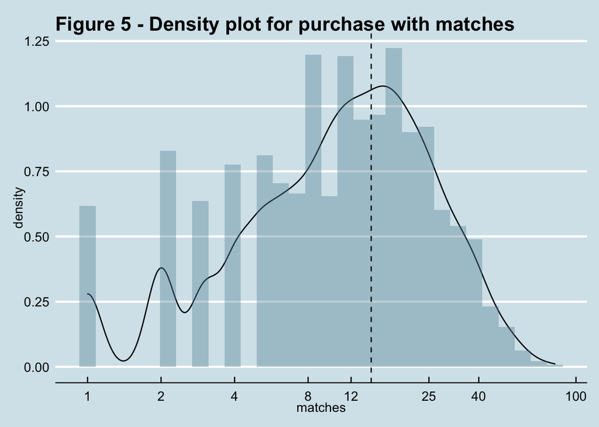

```r
purchased<-user_data%>%
  filter(!is.na(product))%>%
  group_by(userId)%>%
  arrange(date, .by_group = TRUE)%>%
  filter(row_number()==1)%>%
  ungroup()
dist_plot<-purchased%>%
  ggplot(aes(matches))+
  geom_density()+
  geom_histogram(
    aes(y = ..density..),
    alpha = 0.4,
    fill="#6794a7"
  )+
  scale_x_log10(breaks = c(1,2,4,8,12,25,40,100))+
  theme_economist() +
  scale_colour_economist()
dist_plot+
  geom_vline(aes(xintercept = mean(matches, na.rm = TRUE)),
             linetype = "dashed")+
  ggtitle("Figure 5 - Density plot for purchase with matches")
```

The distribution shows that that most users tend to purchase a product between the 5th game and 25th game. The average number of games played prior to first purchase is approx. 14. There is a spike in number of users purchasing a product after 1st, 2nd and 4th game. This could be potentially due to display of shop for test groups at these junctures. Purchase of a product peaks post the 8th game. This activity can be quantified by the empirical Cumulative Distribution Function (eCDF).

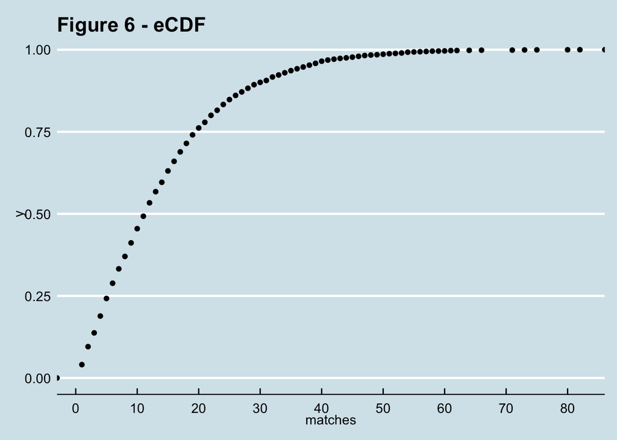

```r
purchased%>%
  ggplot(aes(matches))+
  stat_ecdf(geom='point') +
  scale_x_continuous(breaks = c(0,10,20,30,40,50,60,70,80,90,100))+
  ggtitle("Figure 6 - eCDF")+
  theme_economist() +
  scale_colour_economist()
```

```r
d_fun<-ecdf(purchased$matches)
# probability of purchase before 3rd game
d_fun(3)*100
```

```
## [1] 13.73915
```

```r
# probability of purchase before 5th game
d_fun(5)*100
```

```
## [1] 24.21464
```

```r
# probability of purchase between 5th and 25th game
(d_fun(25)-d_fun(5))*100
```

```
## [1] 60.59161
```

This study shows that 13.7 % of users purchase a product before the 3rd game, 24.21% before the 5th, 60.59 % between 5th to 25th game and the rest later. This data confirms the fact that the purchasing is strongly skewed towards the early stages.

However by splitting the distribution study for each group more insight on the early purchasing activity can be garnered.

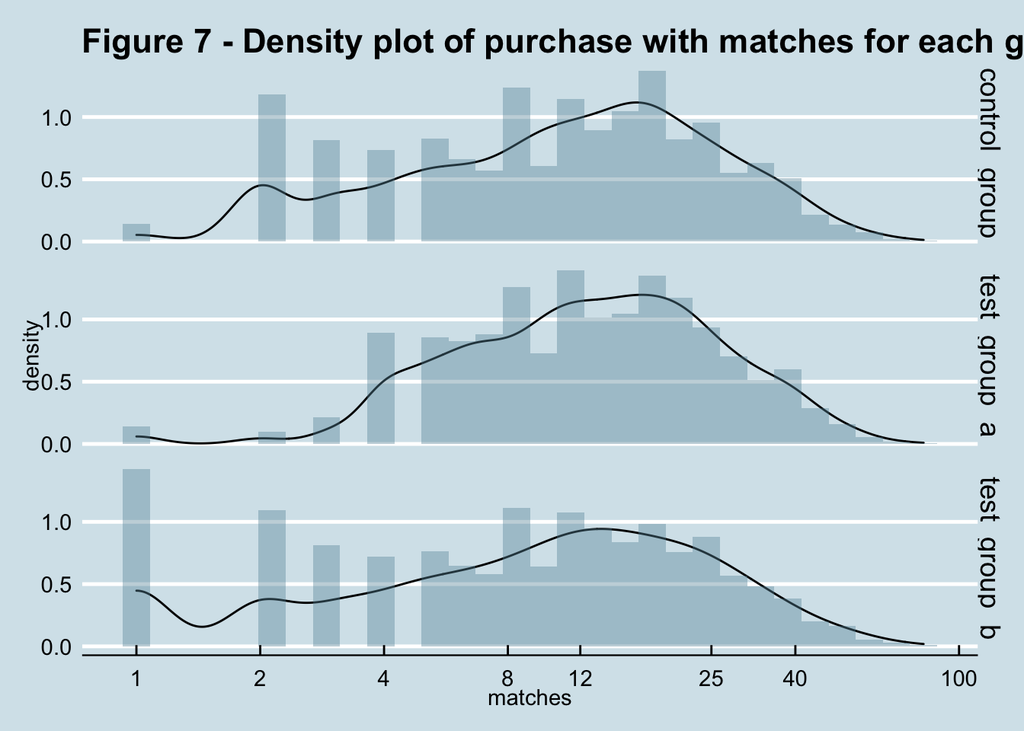

```r
dist_plot+
  facet_grid(rows=vars(abTestGroup))+
  ggtitle("Figure 7 - Density plot of purchase with matches for each group")
```

```r
purchased%>%
  group_by(abTestGroup)%>%
  summarise(
    under_3_matches=ecdf(matches)(3)*100,
    under_5_matches=ecdf(matches)(5)*100,
    between_5_and_25_matches=(ecdf(matches)(25)-ecdf(matches)(5))*100,
    after_25_matches=100-ecdf(matches)(25)*100)%>%
  knitr::kable(caption = "Probability of purchase based on distribution")%>%
  kable_styling()
```

Probability of purchase based on distribution

| abTestGroup | under_3_matches | under_5_matches | between_5_and_25_matches | after_25_matches |
| --- | --- | --- | --- | --- |
| control_group | 14.103032 | 24.40628 | 60.28498 | 15.30873 |
| test_group_a | 2.985075 | 14.51078 | 68.40796 | 17.08126 |
| test_group_b | 21.965699 | 31.76121 | 54.65040 | 13.58839 |

A group wise probability analysis of purchases confirms strong purchasing tendencies when the shop is displayed for the first time.

# 3 Inference

Retention Rate, cumulative ARPU and conversion are highly correlated with higher retention rates leading to higher conversion and subsequently higher cumulative ARPU. As a consequence, achieving higher cumulative ARPU would be possible by improving retention rate.

The ARPU study showed higher rate of increase in cumulative ARPU for the groups control_group and test_group_a in comparison to test_group_b. While this could have been a consequence of higher retention rates for these two groups, the retention studies revealed minimal effect on the retention rate by delaying the display of shop in the long run. However, in the first few days since acquisition test_group_a and control_group performed marginally better than test_group_b in terms of retention. An important conclusion drawn from the retention study is that retention rate decreases rapidly especially in the first few days since acquisition.

The distribution study, on the other hand, shows significant purchasing activity takes place within the first 5 matches, especially when the shop is displayed for the first time. It is imperative to capitalise during this phase. There is a potential for missed conversions when shop is not displayed during this phase.

# 4 Limitation

I have made an assumption with respect to number of matches played prior to purchase of product on a given day. Since, I assumed that products are purchased at the end of a given day after all matches have been played, bias has been introduced in the analysis. To overcome this limitations it will be beneficial to analyse granular data for product purchases that denotes number of matches post which product was purchased.

# 5 Recommendation

## 5.1 Key Recommendation

I recommend displaying the shop to users after 2 matches as is the case with control_group.

As there is significant purchasing activity in the first few matches and retention rate decreases rapidly, display of shop after 4 matches as in the case of test_group_a is not beneficial. It is counter intuitive to assume that a user will purchase a product before engaging with the game. The retention studies also show that retention rate for control_group and test_group_a was slightly higher in the first few days since acquisition and it would be beneficial to capitalise on this margin. Therefore, display of shop post 2 matches as employed in control_group is the best choice for optimising cumulative ARPU.

## 5.2 Additional Recommendation

I recommend that data for in app purchase contain exact number of matches after which purchase was made in addition to date of purchase. This will allow for granular Data Analysis.